# Data Science - Engenharia de Variáveis (Feature Engineering)

## Preparação

Pacotes para aula.

```r
# install.packages("corrplot", dependencies = TRUE)
# install.packages("knitr", dependencies = TRUE)
# install.packages("tidyverse", dependencies = TRUE)
# install.packages("lubridate", dependencies = TRUE)
# install.packages("readr", dependencies = TRUE)
# install.packages("fastDummies", dependencies = TRUE)
# install.packages("skimr", dependencies = TRUE)
# install.packages("factoextra", dependencies = TRUE)

# Carrega pacote
library(corrplot)
library(knitr)
library(tidyverse)
library(lubridate)
library(readr)
library(fastDummies)
library(skimr)
library(factoextra)
library(cluster)
```

## Carregamento e tratamentos iniciais

### Base de dados

Customer Shopping Dataset - Retail Sales Data

Fonte: https://www.kaggle.com/datasets/mehmettahiraslan/customer-shopping-dataset

#### Context

Welcome to the shopping world of Istanbul! Our dataset contains shopping information from 10 different shopping malls between 2021 and 2023. We have gathered data from various age groups and genders to provide a comprehensive view of shopping habits in Istanbul. The dataset includes essential information such as invoice numbers, customer IDs, age, gender, payment methods, product categories, quantity, price, order dates, and shopping mall locations. We hope that this dataset will serve as a valuable resource for researchers, data analysts, and machine learning enthusiasts who want to gain insights into shopping trends and patterns in Istanbul. Explore the dataset and discover the fascinating world of Istanbul shopping!

#### Variáveis

- invoice_no: Invoice number. Nominal. A combination of the letter ‘I’ and a 6-digit integer uniquely assigned to each operation.
- customer_id: Customer number. Nominal. A combination of the letter ‘C’ and a 6-digit integer uniquely assigned to each operation.
- gender: String variable of the customer’s gender.
- age: Positive Integer variable of the customers age.
- category: String variable of the category of the purchased product.
- quantity: The quantities of each product (item) per transaction. Numeric.
- price: Unit price. Numeric. Product price per unit in Turkish Liras (TL).
- payment_method: String variable of the payment method (cash, credit card or debit card) used for the transaction.
- invoice_date: Invoice date. The day when a transaction was generated.
- shopping_mall: String variable of the name of the shopping mall where the transaction was made.

```r
# Carrega o arquivo csv
dados <- read_delim(
  file = "https://www.ufrgs.br/wiki-r/images/3/3d/Customer_shopping_data.csv",
  delim = ","
) %>%
  mutate(
    gender = factor(gender),
    age = as.integer(age),
    category = factor(category),
    payment_method = factor(payment_method),
    invoice_date = dmy(invoice_date),
    shopping_mall = factor(shopping_mall)
  )

# Dados originais
dados %>%
  head(n = 15) %>%
  kable()
```

| invoice_no | customer_id | gender | age | category | quantity | price | payment_method | invoice_date | shopping_mall |
| --- | --- | --- | --- | --- | --- | --- | --- | --- | --- |
| I138884 | C241288 | Female | 28 | Clothing | 5 | 1500.40 | Credit Card | 2022-08-05 | Kanyon |
| I317333 | C111565 | Male | 21 | Shoes | 3 | 1800.51 | Debit Card | 2021-12-12 | Forum Istanbul |
| I127801 | C266599 | Male | 20 | Clothing | 1 | 300.08 | Cash | 2021-11-09 | Metrocity |
| I173702 | C988172 | Female | 66 | Shoes | 5 | 3000.85 | Credit Card | 2021-05-16 | Metropol AVM |
| I337046 | C189076 | Female | 53 | Books | 4 | 60.60 | Cash | 2021-10-24 | Kanyon |
| I227836 | C657758 | Female | 28 | Clothing | 5 | 1500.40 | Credit Card | 2022-05-24 | Forum Istanbul |
| I121056 | C151197 | Female | 49 | Cosmetics | 1 | 40.66 | Cash | 2022-03-13 | Istinye Park |
| I293112 | C176086 | Female | 32 | Clothing | 2 | 600.16 | Credit Card | 2021-01-13 | Mall of Istanbul |
| I293455 | C159642 | Male | 69 | Clothing | 3 | 900.24 | Credit Card | 2021-11-04 | Metrocity |
| I326945 | C283361 | Female | 60 | Clothing | 2 | 600.16 | Credit Card | 2021-08-22 | Kanyon |
| I306368 | C240286 | Female | 36 | Food & Beverage | 2 | 10.46 | Cash | 2022-12-25 | Metrocity |
| I139207 | C191708 | Female | 29 | Books | 1 | 15.15 | Credit Card | 2022-10-28 | Emaar Square Mall |
| I640508 | C225330 | Female | 67 | Toys | 4 | 143.36 | Debit Card | 2022-07-31 | Metrocity |
| I179802 | C312861 | Male | 25 | Clothing | 2 | 600.16 | Cash | 2022-11-17 | Cevahir AVM |
| I336189 | C555402 | Female | 67 | Clothing | 2 | 600.16 | Credit Card | 2022-06-03 | Kanyon |

### Descritivas dos dados antes das transformações

```r
dados %>%
  skim()
```

Data summary

| Name | Piped data |
| --- | --- |
| Number of rows | 99457 |
| Number of columns | 10 |
| _______________________ |  |
| Column type frequency: |  |
| character | 2 |
| Date | 1 |
| factor | 4 |
| numeric | 3 |
| ________________________ |  |
| Group variables | None |

**Variable type: character**

| skim_variable | n_missing | complete_rate | min | max | empty | n_unique | whitespace |
| --- | --- | --- | --- | --- | --- | --- | --- |
| invoice_no | 0 | 1 | 7 | 7 | 0 | 99457 | 0 |
| customer_id | 0 | 1 | 7 | 7 | 0 | 99457 | 0 |

**Variable type: Date**

| skim_variable | n_missing | complete_rate | min | max | median | n_unique |
| --- | --- | --- | --- | --- | --- | --- |
| invoice_date | 0 | 1 | 2021-01-01 | 2023-03-08 | 2022-02-05 | 797 |

**Variable type: factor**

| skim_variable | n_missing | complete_rate | ordered | n_unique | top_counts |
| --- | --- | --- | --- | --- | --- |
| gender | 0 | 1 | FALSE | 2 | Fem: 59482, Mal: 39975 |
| category | 0 | 1 | FALSE | 8 | Clo: 34487, Cos: 15097, Foo: 14776, Toy: 10087 |
| payment_method | 0 | 1 | FALSE | 3 | Cas: 44447, Cre: 34931, Deb: 20079 |
| shopping_mall | 0 | 1 | FALSE | 10 | Mal: 19943, Kan: 19823, Met: 15011, Met: 10161 |

**Variable type: numeric**

| skim_variable | n_missing | complete_rate | mean | sd | p0 | p25 | p50 | p75 | p100 | hist |
| --- | --- | --- | --- | --- | --- | --- | --- | --- | --- | --- |
| age | 0 | 1 | 43.43 | 14.99 | 18.00 | 30.00 | 43.0 | 56.00 | 69 | ▇▇▇▇▇ |
| quantity | 0 | 1 | 3.00 | 1.41 | 1.00 | 2.00 | 3.0 | 4.00 | 5 | ▇▇▇▇▇ |
| price | 0 | 1 | 689.26 | 941.18 | 5.23 | 45.45 | 203.3 | 1200.32 | 5250 | ▇▂▁▁▁ |

#### Remoção de outliers

Remoção do outliers superiores de `price`.

```r
dados <- dados %>%
  filter(
    (price < quantile(price, 0.975))
  )

dados %>%
  skim()
```

Data summary

| Name | Piped data |
| --- | --- |
| Number of rows | 96446 |
| Number of columns | 10 |
| _______________________ |  |
| Column type frequency: |  |
| character | 2 |
| Date | 1 |
| factor | 4 |
| numeric | 3 |
| ________________________ |  |
| Group variables | None |

**Variable type: character**

| skim_variable | n_missing | complete_rate | min | max | empty | n_unique | whitespace |
| --- | --- | --- | --- | --- | --- | --- | --- |
| invoice_no | 0 | 1 | 7 | 7 | 0 | 96446 | 0 |
| customer_id | 0 | 1 | 7 | 7 | 0 | 96446 | 0 |

**Variable type: Date**

| skim_variable | n_missing | complete_rate | min | max | median | n_unique |
| --- | --- | --- | --- | --- | --- | --- |
| invoice_date | 0 | 1 | 2021-01-01 | 2023-03-08 | 2022-02-05 | 797 |

**Variable type: factor**

| skim_variable | n_missing | complete_rate | ordered | n_unique | top_counts |
| --- | --- | --- | --- | --- | --- |
| gender | 0 | 1 | FALSE | 2 | Fem: 57700, Mal: 38746 |
| category | 0 | 1 | FALSE | 8 | Clo: 34487, Cos: 15097, Foo: 14776, Toy: 10087 |
| payment_method | 0 | 1 | FALSE | 3 | Cas: 43101, Cre: 33845, Deb: 19500 |
| shopping_mall | 0 | 1 | FALSE | 10 | Mal: 19324, Kan: 19217, Met: 14558, Met: 9879 |

**Variable type: numeric**

| skim_variable | n_missing | complete_rate | mean | sd | p0 | p25 | p50 | p75 | p100 | hist |
| --- | --- | --- | --- | --- | --- | --- | --- | --- | --- | --- |
| age | 0 | 1 | 43.42 | 15.00 | 18.00 | 30.00 | 43.0 | 56.00 | 69.00 | ▇▇▇▇▇ |
| quantity | 0 | 1 | 2.97 | 1.42 | 1.00 | 2.00 | 3.0 | 4.00 | 5.00 | ▇▇▇▇▇ |
| price | 0 | 1 | 579.74 | 703.09 | 5.23 | 40.66 | 203.3 | 900.24 | 3000.85 | ▇▂▁▁▁ |

## Engenharia de Variáveis (Feature Engineering)

### Transformações $1:1$

Uma variável é utilizada para criar outra variável.

```r
dados <- dados %>%
  mutate(
    # Padronizar variavel numerica
    age_Pad = ((age - mean(age)) / sd(age)),
    quantity_Pad = ((quantity - mean(quantity)) / sd(quantity)),
    price_Pad = ((price - mean(price)) / sd(price)),

    # Datas
    DiaDaSemana = invoice_date %>%
      weekdays() %>%
      factor(),
    Mes = invoice_date %>%
      month() %>%
      factor(),
    Trimestre = invoice_date %>%
      quarter() %>%
      factor(),
    Semestre = invoice_date %>%
      semester() %>%
      factor(),
    Ano = invoice_date %>%
      year() %>%
      factor(),
    Feriado = ifelse(
      test = invoice_date %in% c(
        "2020-09-10",
        "2023-09-01",
        "2019-07-01"
      ),
      yes = TRUE,
      no = FALSE
    ),
    VesperaFeriado = ifelse(
      test = invoice_date %in% c(
        "2020-09-09",
        "2023-08-31",
        "2019-06-30"
      ),
      yes = TRUE,
      no = FALSE
    )
  )

# Exibe os dados
dados %>%
  head(n = 15) %>%
  kable()
```

| invoice_no | customer_id | gender | age | category | quantity | price | payment_method | invoice_date | shopping_mall | age_Pad | quantity_Pad | price_Pad | DiaDaSemana | Mes | Trimestre | Semestre | Ano | Feriado | VesperaFeriado |
| --- | --- | --- | --- | --- | --- | --- | --- | --- | --- | --- | --- | --- | --- | --- | --- | --- | --- | --- | --- |
| I138884 | C241288 | Female | 28 | Clothing | 5 | 1500.40 | Credit Card | 2022-08-05 | Kanyon | -1.0285875 | 1.4314668 | 1.3094570 | sexta-feira | 8 | 3 | 2 | 2022 | FALSE | FALSE |
| I317333 | C111565 | Male | 21 | Shoes | 3 | 1800.51 | Debit Card | 2021-12-12 | Forum Istanbul | -1.4953982 | 0.0194860 | 1.7363040 | domingo | 12 | 4 | 2 | 2021 | FALSE | FALSE |
| I127801 | C266599 | Male | 20 | Clothing | 1 | 300.08 | Cash | 2021-11-09 | Metrocity | -1.5620855 | -1.3924948 | -0.3977604 | terça-feira | 11 | 4 | 2 | 2021 | FALSE | FALSE |
| I173702 | C988172 | Female | 66 | Shoes | 5 | 3000.85 | Credit Card | 2021-05-16 | Metropol AVM | 1.5055279 | 1.4314668 | 3.4435499 | domingo | 5 | 2 | 1 | 2021 | FALSE | FALSE |
| I337046 | C189076 | Female | 53 | Books | 4 | 60.60 | Cash | 2021-10-24 | Kanyon | 0.6385937 | 0.7254764 | -0.7383732 | domingo | 10 | 4 | 2 | 2021 | FALSE | FALSE |
| I227836 | C657758 | Female | 28 | Clothing | 5 | 1500.40 | Credit Card | 2022-05-24 | Forum Istanbul | -1.0285875 | 1.4314668 | 1.3094570 | terça-feira | 5 | 2 | 1 | 2022 | FALSE | FALSE |
| I121056 | C151197 | Female | 49 | Cosmetics | 1 | 40.66 | Cash | 2022-03-13 | Istinye Park | 0.3718447 | -1.3924948 | -0.7667339 | domingo | 3 | 1 | 1 | 2022 | FALSE | FALSE |
| I293112 | C176086 | Female | 32 | Clothing | 2 | 600.16 | Credit Card | 2021-01-13 | Mall of Istanbul | -0.7618385 | -0.6865044 | 0.0290440 | quarta-feira | 1 | 1 | 1 | 2021 | FALSE | FALSE |
| I293455 | C159642 | Male | 69 | Clothing | 3 | 900.24 | Credit Card | 2021-11-04 | Metrocity | 1.7055897 | 0.0194860 | 0.4558483 | quinta-feira | 11 | 4 | 2 | 2021 | FALSE | FALSE |
| I326945 | C283361 | Female | 60 | Clothing | 2 | 600.16 | Credit Card | 2021-08-22 | Kanyon | 1.1054044 | -0.6865044 | 0.0290440 | domingo | 8 | 3 | 2 | 2021 | FALSE | FALSE |
| I306368 | C240286 | Female | 36 | Food & Beverage | 2 | 10.46 | Cash | 2022-12-25 | Metrocity | -0.4950895 | -0.6865044 | -0.8096875 | domingo | 12 | 4 | 2 | 2022 | FALSE | FALSE |
| I139207 | C191708 | Female | 29 | Books | 1 | 15.15 | Credit Card | 2022-10-28 | Emaar Square Mall | -0.9619002 | -1.3924948 | -0.8030169 | sexta-feira | 10 | 4 | 2 | 2022 | FALSE | FALSE |
| I640508 | C225330 | Female | 67 | Toys | 4 | 143.36 | Debit Card | 2022-07-31 | Metrocity | 1.5722152 | 0.7254764 | -0.6206635 | domingo | 7 | 3 | 2 | 2022 | FALSE | FALSE |
| I179802 | C312861 | Male | 25 | Clothing | 2 | 600.16 | Cash | 2022-11-17 | Cevahir AVM | -1.2286492 | -0.6865044 | 0.0290440 | quinta-feira | 11 | 4 | 2 | 2022 | FALSE | FALSE |
| I336189 | C555402 | Female | 67 | Clothing | 2 | 600.16 | Credit Card | 2022-06-03 | Kanyon | 1.5722152 | -0.6865044 | 0.0290440 | sexta-feira | 6 | 2 | 1 | 2022 | FALSE | FALSE |

### Transformações $1:N$

Uma variável é utilizada para criar $N$ variáveis. O exemplo é de one hot encoding, no qual variáveis categóricas geram variáveis dummies (0 ou 1).

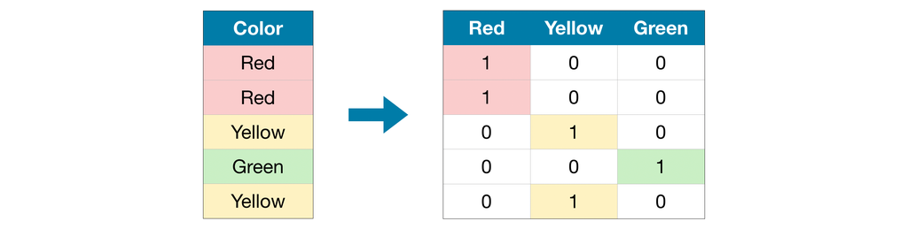

```r
dados <- dados %>%
  dummy_cols(
    select_columns = c("gender", "category", "payment_method", "shopping_mall", "DiaDaSemana", "Mes", "Trimestre", "Semestre"),
    remove_first_dummy = FALSE,
    remove_most_frequent_dummy = FALSE,
    remove_selected_columns = FALSE # Normalmente é TRUE, aqui estamos apresentando por partes para didática
  )

# Exibe os dados
dados %>%
  head(n = 15) %>%
  kable()
```

| invoice_no | customer_id | gender | age | category | quantity | price | payment_method | invoice_date | shopping_mall | age_Pad | quantity_Pad | price_Pad | DiaDaSemana | Mes | Trimestre | Semestre | Ano | Feriado | VesperaFeriado | gender_Female | gender_Male | category_Books | category_Clothing | category_Cosmetics | category_Food & Beverage | category_Shoes | category_Souvenir | category_Technology | category_Toys | … |
| --- | --- | --- | --- | --- | --- | --- | --- | --- | --- | --- | --- | --- | --- | --- | --- | --- | --- | --- | --- | --- | --- | --- | --- | --- | --- | --- | --- | --- | --- | --- |
| I138884 | C241288 | Female | 28 | Clothing | 5 | 1500.40 | Credit Card | 2022-08-05 | Kanyon | -1.0285875 | 1.4314668 | 1.3094570 | sexta-feira | 8 | 3 | 2 | 2022 | FALSE | FALSE | 1 | 0 | 0 | 1 | 0 | 0 | 0 | 0 | 0 | 0 | … |
| I317333 | C111565 | Male | 21 | Shoes | 3 | 1800.51 | Debit Card | 2021-12-12 | Forum Istanbul | -1.4953982 | 0.0194860 | 1.7363040 | domingo | 12 | 4 | 2 | 2021 | FALSE | FALSE | 0 | 1 | 0 | 0 | 0 | 0 | 1 | 0 | 0 | 0 | … |
| I127801 | C266599 | Male | 20 | Clothing | 1 | 300.08 | Cash | 2021-11-09 | Metrocity | -1.5620855 | -1.3924948 | -0.3977604 | terça-feira | 11 | 4 | 2 | 2021 | FALSE | FALSE | 0 | 1 | 0 | 1 | 0 | 0 | 0 | 0 | 0 | 0 | … |
| I173702 | C988172 | Female | 66 | Shoes | 5 | 3000.85 | Credit Card | 2021-05-16 | Metropol AVM | 1.5055279 | 1.4314668 | 3.4435499 | domingo | 5 | 2 | 1 | 2021 | FALSE | FALSE | 1 | 0 | 0 | 0 | 0 | 0 | 1 | 0 | 0 | 0 | … |
| I337046 | C189076 | Female | 53 | Books | 4 | 60.60 | Cash | 2021-10-24 | Kanyon | 0.6385937 | 0.7254764 | -0.7383732 | domingo | 10 | 4 | 2 | 2021 | FALSE | FALSE | 1 | 0 | 1 | 0 | 0 | 0 | 0 | 0 | 0 | 0 | … |
| I227836 | C657758 | Female | 28 | Clothing | 5 | 1500.40 | Credit Card | 2022-05-24 | Forum Istanbul | -1.0285875 | 1.4314668 | 1.3094570 | terça-feira | 5 | 2 | 1 | 2022 | FALSE | FALSE | 1 | 0 | 0 | 1 | 0 | 0 | 0 | 0 | 0 | 0 | … |
| I121056 | C151197 | Female | 49 | Cosmetics | 1 | 40.66 | Cash | 2022-03-13 | Istinye Park | 0.3718447 | -1.3924948 | -0.7667339 | domingo | 3 | 1 | 1 | 2022 | FALSE | FALSE | 1 | 0 | 0 | 0 | 1 | 0 | 0 | 0 | 0 | 0 | … |
| I293112 | C176086 | Female | 32 | Clothing | 2 | 600.16 | Credit Card | 2021-01-13 | Mall of Istanbul | -0.7618385 | -0.6865044 | 0.0290440 | quarta-feira | 1 | 1 | 1 | 2021 | FALSE | FALSE | 1 | 0 | 0 | 1 | 0 | 0 | 0 | 0 | 0 | 0 | … |
| I293455 | C159642 | Male | 69 | Clothing | 3 | 900.24 | Credit Card | 2021-11-04 | Metrocity | 1.7055897 | 0.0194860 | 0.4558483 | quinta-feira | 11 | 4 | 2 | 2021 | FALSE | FALSE | 0 | 1 | 0 | 1 | 0 | 0 | 0 | 0 | 0 | 0 | … |
| I326945 | C283361 | Female | 60 | Clothing | 2 | 600.16 | Credit Card | 2021-08-22 | Kanyon | 1.1054044 | -0.6865044 | 0.0290440 | domingo | 8 | 3 | 2 | 2021 | FALSE | FALSE | 1 | 0 | 0 | 1 | 0 | 0 | 0 | 0 | 0 | 0 | … |
| I306368 | C240286 | Female | 36 | Food & Beverage | 2 | 10.46 | Cash | 2022-12-25 | Metrocity | -0.4950895 | -0.6865044 | -0.8096875 | domingo | 12 | 4 | 2 | 2022 | FALSE | FALSE | 1 | 0 | 0 | 0 | 0 | 1 | 0 | 0 | 0 | 0 | … |
| I139207 | C191708 | Female | 29 | Books | 1 | 15.15 | Credit Card | 2022-10-28 | Emaar Square Mall | -0.9619002 | -1.3924948 | -0.8030169 | sexta-feira | 10 | 4 | 2 | 2022 | FALSE | FALSE | 1 | 0 | 1 | 0 | 0 | 0 | 0 | 0 | 0 | 0 | … |
| I640508 | C225330 | Female | 67 | Toys | 4 | 143.36 | Debit Card | 2022-07-31 | Metrocity | 1.5722152 | 0.7254764 | -0.6206635 | domingo | 7 | 3 | 2 | 2022 | FALSE | FALSE | 1 | 0 | 0 | 0 | 0 | 0 | 0 | 0 | 0 | 1 | … |
| I179802 | C312861 | Male | 25 | Clothing | 2 | 600.16 | Cash | 2022-11-17 | Cevahir AVM | -1.2286492 | -0.6865044 | 0.0290440 | quinta-feira | 11 | 4 | 2 | 2022 | FALSE | FALSE | 0 | 1 | 0 | 1 | 0 | 0 | 0 | 0 | 0 | 0 | … |
| I336189 | C555402 | Female | 67 | Clothing | 2 | 600.16 | Credit Card | 2022-06-03 | Kanyon | 1.5722152 | -0.6865044 | 0.0290440 | sexta-feira | 6 | 2 | 1 | 2022 | FALSE | FALSE | 1 | 0 | 0 | 1 | 0 | 0 | 0 | 0 | 0 | 0 | … |

### Transformações $N:1$

Quando $N$ variáveis dão origem a $1$ variável nova. No exemplo temos a variável `PrecoMedio` gerada pela divisão do `price` pela `quantity`. Nós também criamos a variável `PrecoMedio_Pad` contendo a variável `PrecoMedio` padronizada em $z-score$.

```r
dados <- dados %>%
  mutate(
    PrecoMedio = (price / quantity),
    PrecoMedio_Pad = (PrecoMedio - mean(PrecoMedio)) / sd(PrecoMedio),
    PrecoMedio_Pad_x_age_Pad = (PrecoMedio_Pad * age_Pad),
    Quantity_x_Mes1 = quantity * Mes_1
  )

# Exibe os dados
dados %>%
  head(n = 15) %>%
  kable()
```

| invoice_no | customer_id | gender | age | category | quantity | price | payment_method | invoice_date | shopping_mall | age_Pad | quantity_Pad | price_Pad | DiaDaSemana | Mes | Trimestre | Semestre | Ano | Feriado | VesperaFeriado | gender_Female | gender_Male | category_Books | category_Clothing | category_Cosmetics | category_Food & Beverage | category_Shoes | category_Souvenir | category_Technology | category_Toys | … |
| --- | --- | --- | --- | --- | --- | --- | --- | --- | --- | --- | --- | --- | --- | --- | --- | --- | --- | --- | --- | --- | --- | --- | --- | --- | --- | --- | --- | --- | --- | --- |
| I138884 | C241288 | Female | 28 | Clothing | 5 | 1500.40 | Credit Card | 2022-08-05 | Kanyon | -1.0285875 | 1.4314668 | 1.3094570 | sexta-feira | 8 | 3 | 2 | 2022 | FALSE | FALSE | 1 | 0 | 0 | 1 | 0 | 0 | 0 | 0 | 0 | 0 | … |
| I317333 | C111565 | Male | 21 | Shoes | 3 | 1800.51 | Debit Card | 2021-12-12 | Forum Istanbul | -1.4953982 | 0.0194860 | 1.7363040 | domingo | 12 | 4 | 2 | 2021 | FALSE | FALSE | 0 | 1 | 0 | 0 | 0 | 0 | 1 | 0 | 0 | 0 | … |
| I127801 | C266599 | Male | 20 | Clothing | 1 | 300.08 | Cash | 2021-11-09 | Metrocity | -1.5620855 | -1.3924948 | -0.3977604 | terça-feira | 11 | 4 | 2 | 2021 | FALSE | FALSE | 0 | 1 | 0 | 1 | 0 | 0 | 0 | 0 | 0 | 0 | … |
| I173702 | C988172 | Female | 66 | Shoes | 5 | 3000.85 | Credit Card | 2021-05-16 | Metropol AVM | 1.5055279 | 1.4314668 | 3.4435499 | domingo | 5 | 2 | 1 | 2021 | FALSE | FALSE | 1 | 0 | 0 | 0 | 0 | 0 | 1 | 0 | 0 | 0 | … |
| I337046 | C189076 | Female | 53 | Books | 4 | 60.60 | Cash | 2021-10-24 | Kanyon | 0.6385937 | 0.7254764 | -0.7383732 | domingo | 10 | 4 | 2 | 2021 | FALSE | FALSE | 1 | 0 | 1 | 0 | 0 | 0 | 0 | 0 | 0 | 0 | … |
| I227836 | C657758 | Female | 28 | Clothing | 5 | 1500.40 | Credit Card | 2022-05-24 | Forum Istanbul | -1.0285875 | 1.4314668 | 1.3094570 | terça-feira | 5 | 2 | 1 | 2022 | FALSE | FALSE | 1 | 0 | 0 | 1 | 0 | 0 | 0 | 0 | 0 | 0 | … |
| I121056 | C151197 | Female | 49 | Cosmetics | 1 | 40.66 | Cash | 2022-03-13 | Istinye Park | 0.3718447 | -1.3924948 | -0.7667339 | domingo | 3 | 1 | 1 | 2022 | FALSE | FALSE | 1 | 0 | 0 | 0 | 1 | 0 | 0 | 0 | 0 | 0 | … |
| I293112 | C176086 | Female | 32 | Clothing | 2 | 600.16 | Credit Card | 2021-01-13 | Mall of Istanbul | -0.7618385 | -0.6865044 | 0.0290440 | quarta-feira | 1 | 1 | 1 | 2021 | FALSE | FALSE | 1 | 0 | 0 | 1 | 0 | 0 | 0 | 0 | 0 | 0 | … |
| I293455 | C159642 | Male | 69 | Clothing | 3 | 900.24 | Credit Card | 2021-11-04 | Metrocity | 1.7055897 | 0.0194860 | 0.4558483 | quinta-feira | 11 | 4 | 2 | 2021 | FALSE | FALSE | 0 | 1 | 0 | 1 | 0 | 0 | 0 | 0 | 0 | 0 | … |
| I326945 | C283361 | Female | 60 | Clothing | 2 | 600.16 | Credit Card | 2021-08-22 | Kanyon | 1.1054044 | -0.6865044 | 0.0290440 | domingo | 8 | 3 | 2 | 2021 | FALSE | FALSE | 1 | 0 | 0 | 1 | 0 | 0 | 0 | 0 | 0 | 0 | … |
| I306368 | C240286 | Female | 36 | Food & Beverage | 2 | 10.46 | Cash | 2022-12-25 | Metrocity | -0.4950895 | -0.6865044 | -0.8096875 | domingo | 12 | 4 | 2 | 2022 | FALSE | FALSE | 1 | 0 | 0 | 0 | 0 | 1 | 0 | 0 | 0 | 0 | … |
| I139207 | C191708 | Female | 29 | Books | 1 | 15.15 | Credit Card | 2022-10-28 | Emaar Square Mall | -0.9619002 | -1.3924948 | -0.8030169 | sexta-feira | 10 | 4 | 2 | 2022 | FALSE | FALSE | 1 | 0 | 1 | 0 | 0 | 0 | 0 | 0 | 0 | 0 | … |
| I640508 | C225330 | Female | 67 | Toys | 4 | 143.36 | Debit Card | 2022-07-31 | Metrocity | 1.5722152 | 0.7254764 | -0.6206635 | domingo | 7 | 3 | 2 | 2022 | FALSE | FALSE | 1 | 0 | 0 | 0 | 0 | 0 | 0 | 0 | 0 | 1 | … |
| I179802 | C312861 | Male | 25 | Clothing | 2 | 600.16 | Cash | 2022-11-17 | Cevahir AVM | -1.2286492 | -0.6865044 | 0.0290440 | quinta-feira | 11 | 4 | 2 | 2022 | FALSE | FALSE | 0 | 1 | 0 | 1 | 0 | 0 | 0 | 0 | 0 | 0 | … |
| I336189 | C555402 | Female | 67 | Clothing | 2 | 600.16 | Credit Card | 2022-06-03 | Kanyon | 1.5722152 | -0.6865044 | 0.0290440 | sexta-feira | 6 | 2 | 1 | 2022 | FALSE | FALSE | 1 | 0 | 0 | 1 | 0 | 0 | 0 | 0 | 0 | 0 | … |

### Descritivas dos dados depois das transformações

```r
dados %>%
  skim()
```

Data summary

| Name | Piped data |
| --- | --- |
| Number of rows | 96446 |
| Number of columns | 72 |
| _______________________ |  |
| Column type frequency: |  |
| character | 2 |
| Date | 1 |
| factor | 9 |
| logical | 2 |
| numeric | 58 |
| ________________________ |  |
| Group variables | None |

**Variable type: character**

| skim_variable | n_missing | complete_rate | min | max | empty | n_unique | whitespace |
| --- | --- | --- | --- | --- | --- | --- | --- |
| invoice_no | 0 | 1 | 7 | 7 | 0 | 96446 | 0 |
| customer_id | 0 | 1 | 7 | 7 | 0 | 96446 | 0 |

**Variable type: Date**

| skim_variable | n_missing | complete_rate | min | max | median | n_unique |
| --- | --- | --- | --- | --- | --- | --- |
| invoice_date | 0 | 1 | 2021-01-01 | 2023-03-08 | 2022-02-05 | 797 |

**Variable type: factor**

| skim_variable | n_missing | complete_rate | ordered | n_unique | top_counts |
| --- | --- | --- | --- | --- | --- |
| gender | 0 | 1 | FALSE | 2 | Fem: 57700, Mal: 38746 |
| category | 0 | 1 | FALSE | 8 | Clo: 34487, Cos: 15097, Foo: 14776, Toy: 10087 |
| payment_method | 0 | 1 | FALSE | 3 | Cas: 43101, Cre: 33845, Deb: 19500 |
| shopping_mall | 0 | 1 | FALSE | 10 | Mal: 19324, Kan: 19217, Met: 14558, Met: 9879 |
| DiaDaSemana | 0 | 1 | FALSE | 7 | sex: 13940, seg: 13916, ter: 13789, dom: 13718 |
| Mes | 0 | 1 | FALSE | 12 | 1: 11253, 2: 10164, 3: 8489, 7: 7646 |
| Trimestre | 0 | 1 | FALSE | 4 | 1: 29906, 4: 22291, 3: 22153, 2: 22096 |
| Semestre | 0 | 1 | FALSE | 2 | 1: 52002, 2: 44444 |
| Ano | 0 | 1 | FALSE | 3 | 202: 44182, 202: 44020, 202: 8244 |

**Variable type: logical**

| skim_variable | n_missing | complete_rate | mean | count |
| --- | --- | --- | --- | --- |
| Feriado | 0 | 1 | 0 | FAL: 96446 |
| VesperaFeriado | 0 | 1 | 0 | FAL: 96446 |

**Variable type: numeric**

| skim_variable | n_missing | complete_rate | mean | sd | p0 | p25 | p50 | p75 | p100 | hist |
| --- | --- | --- | --- | --- | --- | --- | --- | --- | --- | --- |
| age | 0 | 1 | 43.42 | 15.00 | 18.00 | 30.00 | 43.00 | 56.00 | 69.00 | ▇▇▇▇▇ |
| quantity | 0 | 1 | 2.97 | 1.42 | 1.00 | 2.00 | 3.00 | 4.00 | 5.00 | ▇▇▇▇▇ |
| price | 0 | 1 | 579.74 | 703.09 | 5.23 | 40.66 | 203.30 | 900.24 | 3000.85 | ▇▂▁▁▁ |
| age_Pad | 0 | 1 | 0.00 | 1.00 | -1.70 | -0.90 | -0.03 | 0.84 | 1.71 | ▇▇▇▇▇ |
| quantity_Pad | 0 | 1 | 0.00 | 1.00 | -1.39 | -0.69 | 0.02 | 0.73 | 1.43 | ▇▇▇▇▇ |
| price_Pad | 0 | 1 | 0.00 | 1.00 | -0.82 | -0.77 | -0.54 | 0.46 | 3.44 | ▇▂▁▁▁ |
| gender_Female | 0 | 1 | 0.60 | 0.49 | 0.00 | 0.00 | 1.00 | 1.00 | 1.00 | ▆▁▁▁▇ |
| gender_Male | 0 | 1 | 0.40 | 0.49 | 0.00 | 0.00 | 0.00 | 1.00 | 1.00 | ▇▁▁▁▆ |
| category_Books | 0 | 1 | 0.05 | 0.22 | 0.00 | 0.00 | 0.00 | 0.00 | 1.00 | ▇▁▁▁▁ |
| category_Clothing | 0 | 1 | 0.36 | 0.48 | 0.00 | 0.00 | 0.00 | 1.00 | 1.00 | ▇▁▁▁▅ |
| category_Cosmetics | 0 | 1 | 0.16 | 0.36 | 0.00 | 0.00 | 0.00 | 0.00 | 1.00 | ▇▁▁▁▂ |
| category_Food & Beverage | 0 | 1 | 0.15 | 0.36 | 0.00 | 0.00 | 0.00 | 0.00 | 1.00 | ▇▁▁▁▂ |
| category_Shoes | 0 | 1 | 0.10 | 0.31 | 0.00 | 0.00 | 0.00 | 0.00 | 1.00 | ▇▁▁▁▁ |
| category_Souvenir | 0 | 1 | 0.05 | 0.22 | 0.00 | 0.00 | 0.00 | 0.00 | 1.00 | ▇▁▁▁▁ |
| category_Technology | 0 | 1 | 0.02 | 0.14 | 0.00 | 0.00 | 0.00 | 0.00 | 1.00 | ▇▁▁▁▁ |
| category_Toys | 0 | 1 | 0.10 | 0.31 | 0.00 | 0.00 | 0.00 | 0.00 | 1.00 | ▇▁▁▁▁ |
| payment_method_Cash | 0 | 1 | 0.45 | 0.50 | 0.00 | 0.00 | 0.00 | 1.00 | 1.00 | ▇▁▁▁▆ |
| payment_method_Credit Card | 0 | 1 | 0.35 | 0.48 | 0.00 | 0.00 | 0.00 | 1.00 | 1.00 | ▇▁▁▁▅ |
| payment_method_Debit Card | 0 | 1 | 0.20 | 0.40 | 0.00 | 0.00 | 0.00 | 0.00 | 1.00 | ▇▁▁▁▂ |
| shopping_mall_Cevahir AVM | 0 | 1 | 0.05 | 0.22 | 0.00 | 0.00 | 0.00 | 0.00 | 1.00 | ▇▁▁▁▁ |
| shopping_mall_Emaar Square Mall | 0 | 1 | 0.05 | 0.21 | 0.00 | 0.00 | 0.00 | 0.00 | 1.00 | ▇▁▁▁▁ |
| shopping_mall_Forum Istanbul | 0 | 1 | 0.05 | 0.22 | 0.00 | 0.00 | 0.00 | 0.00 | 1.00 | ▇▁▁▁▁ |
| shopping_mall_Istinye Park | 0 | 1 | 0.10 | 0.30 | 0.00 | 0.00 | 0.00 | 0.00 | 1.00 | ▇▁▁▁▁ |
| shopping_mall_Kanyon | 0 | 1 | 0.20 | 0.40 | 0.00 | 0.00 | 0.00 | 0.00 | 1.00 | ▇▁▁▁▂ |
| shopping_mall_Mall of Istanbul | 0 | 1 | 0.20 | 0.40 | 0.00 | 0.00 | 0.00 | 0.00 | 1.00 | ▇▁▁▁▂ |
| shopping_mall_Metrocity | 0 | 1 | 0.15 | 0.36 | 0.00 | 0.00 | 0.00 | 0.00 | 1.00 | ▇▁▁▁▂ |
| shopping_mall_Metropol AVM | 0 | 1 | 0.10 | 0.30 | 0.00 | 0.00 | 0.00 | 0.00 | 1.00 | ▇▁▁▁▁ |
| shopping_mall_Viaport Outlet | 0 | 1 | 0.05 | 0.22 | 0.00 | 0.00 | 0.00 | 0.00 | 1.00 | ▇▁▁▁▁ |
| shopping_mall_Zorlu Center | 0 | 1 | 0.05 | 0.22 | 0.00 | 0.00 | 0.00 | 0.00 | 1.00 | ▇▁▁▁▁ |
| DiaDaSemana_domingo | 0 | 1 | 0.14 | 0.35 | 0.00 | 0.00 | 0.00 | 0.00 | 1.00 | ▇▁▁▁▁ |
| DiaDaSemana_quarta-feira | 0 | 1 | 0.14 | 0.35 | 0.00 | 0.00 | 0.00 | 0.00 | 1.00 | ▇▁▁▁▁ |
| DiaDaSemana_quinta-feira | 0 | 1 | 0.14 | 0.35 | 0.00 | 0.00 | 0.00 | 0.00 | 1.00 | ▇▁▁▁▁ |
| DiaDaSemana_sábado | 0 | 1 | 0.14 | 0.35 | 0.00 | 0.00 | 0.00 | 0.00 | 1.00 | ▇▁▁▁▁ |
| DiaDaSemana_segunda-feira | 0 | 1 | 0.14 | 0.35 | 0.00 | 0.00 | 0.00 | 0.00 | 1.00 | ▇▁▁▁▂ |
| DiaDaSemana_sexta-feira | 0 | 1 | 0.14 | 0.35 | 0.00 | 0.00 | 0.00 | 0.00 | 1.00 | ▇▁▁▁▂ |
| DiaDaSemana_terça-feira | 0 | 1 | 0.14 | 0.35 | 0.00 | 0.00 | 0.00 | 0.00 | 1.00 | ▇▁▁▁▂ |
| Mes_1 | 0 | 1 | 0.12 | 0.32 | 0.00 | 0.00 | 0.00 | 0.00 | 1.00 | ▇▁▁▁▁ |
| Mes_2 | 0 | 1 | 0.11 | 0.31 | 0.00 | 0.00 | 0.00 | 0.00 | 1.00 | ▇▁▁▁▁ |
| Mes_3 | 0 | 1 | 0.09 | 0.28 | 0.00 | 0.00 | 0.00 | 0.00 | 1.00 | ▇▁▁▁▁ |
| Mes_4 | 0 | 1 | 0.08 | 0.26 | 0.00 | 0.00 | 0.00 | 0.00 | 1.00 | ▇▁▁▁▁ |
| Mes_5 | 0 | 1 | 0.08 | 0.27 | 0.00 | 0.00 | 0.00 | 0.00 | 1.00 | ▇▁▁▁▁ |
| Mes_6 | 0 | 1 | 0.08 | 0.27 | 0.00 | 0.00 | 0.00 | 0.00 | 1.00 | ▇▁▁▁▁ |
| Mes_7 | 0 | 1 | 0.08 | 0.27 | 0.00 | 0.00 | 0.00 | 0.00 | 1.00 | ▇▁▁▁▁ |
| Mes_8 | 0 | 1 | 0.08 | 0.27 | 0.00 | 0.00 | 0.00 | 0.00 | 1.00 | ▇▁▁▁▁ |
| Mes_9 | 0 | 1 | 0.07 | 0.26 | 0.00 | 0.00 | 0.00 | 0.00 | 1.00 | ▇▁▁▁▁ |
| Mes_10 | 0 | 1 | 0.08 | 0.27 | 0.00 | 0.00 | 0.00 | 0.00 | 1.00 | ▇▁▁▁▁ |
| Mes_11 | 0 | 1 | 0.08 | 0.27 | 0.00 | 0.00 | 0.00 | 0.00 | 1.00 | ▇▁▁▁▁ |
| Mes_12 | 0 | 1 | 0.08 | 0.27 | 0.00 | 0.00 | 0.00 | 0.00 | 1.00 | ▇▁▁▁▁ |
| Trimestre_1 | 0 | 1 | 0.31 | 0.46 | 0.00 | 0.00 | 0.00 | 1.00 | 1.00 | ▇▁▁▁▃ |
| Trimestre_2 | 0 | 1 | 0.23 | 0.42 | 0.00 | 0.00 | 0.00 | 0.00 | 1.00 | ▇▁▁▁▂ |
| Trimestre_3 | 0 | 1 | 0.23 | 0.42 | 0.00 | 0.00 | 0.00 | 0.00 | 1.00 | ▇▁▁▁▂ |
| Trimestre_4 | 0 | 1 | 0.23 | 0.42 | 0.00 | 0.00 | 0.00 | 0.00 | 1.00 | ▇▁▁▁▂ |
| Semestre_1 | 0 | 1 | 0.54 | 0.50 | 0.00 | 0.00 | 1.00 | 1.00 | 1.00 | ▇▁▁▁▇ |
| Semestre_2 | 0 | 1 | 0.46 | 0.50 | 0.00 | 0.00 | 0.00 | 1.00 | 1.00 | ▇▁▁▁▇ |
| PrecoMedio | 0 | 1 | 203.66 | 226.51 | 5.23 | 15.15 | 40.66 | 300.08 | 1050.00 | ▇▆▂▁▁ |
| PrecoMedio_Pad | 0 | 1 | 0.00 | 1.00 | -0.88 | -0.83 | -0.72 | 0.43 | 3.74 | ▇▆▂▁▁ |
| PrecoMedio_Pad_x_age_Pad | 0 | 1 | 0.00 | 1.00 | -6.34 | -0.55 | 0.02 | 0.56 | 6.37 | ▁▁▇▁▁ |
| Quantity_x_Mes1 | 0 | 1 | 0.35 | 1.07 | 0.00 | 0.00 | 0.00 | 0.00 | 5.00 | ▇▁▁▁▁ |

## Transformações $N:N$ (PCA)

$N$ variáveis dão origem a novas $N$ variáveis. Esse é o caso da técnica PCA (Principal Component Analysis) que simplifica a análise de dados, reduzindo sua dimensionalidade. Ele encontra novos eixos que maximizam a variabilidade dos dados e são ortogonais entre si. Esses novos eixos, chamados de componentes principais, representam uma projeção dos dados originais em um espaço de menor dimensão. O PCA é útil para visualização, remoção de ruídos, compressão de dados e preparação de dados para algoritmos de aprendizado de máquina.

Na engenharia de variáveis, o PCA pode ser aplicado para combinar variáveis correlacionadas em um único componente, reduzindo a multicolinearidade. Também é útil para eliminar variáveis redundantes, simplificando modelos e os tornando mais interpretáveis. Além disso, o PCA pode ser empregado para identificar as características mais importantes de um conjunto de dados, selecionando apenas os componentes principais mais significativos, economizando recursos computacionais e melhorando a eficiência do processo de análise.

### Dados para PCA

```r
# Dados para PCA
dadosParaPCA <- dados %>%
  select(
    ends_with("_Pad"),
    starts_with("gender_"),
    starts_with("category_"),
    starts_with("payment_method_"),
    starts_with("category_"),
    starts_with("shopping_mall_"),
    starts_with("DiaDaSemana_"),
    starts_with("Mes_"),
    starts_with("Trimestre_"),
    starts_with("Semestre_")
  )
```

### Correlações

```r
# Atribui codigos para as variaveis
codVariavel <- str_pad(
  string = 1L:ncol(dadosParaPCA),
  width = 2,
  pad = "0"
)

# Tabela de codigos e variaveis
variaveis <- tibble(
  CodVariavel = codVariavel,
  Variaveis = colnames(dadosParaPCA)
)

# Visualizar codigo e nome das variaveis
variaveis %>%
  kable()
```

| CodVariavel | Variaveis |
| --- | --- |
| 01 | age_Pad |
| 02 | quantity_Pad |
| 03 | price_Pad |
| 04 | PrecoMedio_Pad |
| 05 | PrecoMedio_Pad_x_age_Pad |
| 06 | gender_Female |
| 07 | gender_Male |
| 08 | category_Books |
| 09 | category_Clothing |
| 10 | category_Cosmetics |
| 11 | category_Food & Beverage |
| 12 | category_Shoes |
| 13 | category_Souvenir |
| 14 | category_Technology |
| 15 | category_Toys |
| 16 | payment_method_Cash |
| 17 | payment_method_Credit Card |
| 18 | payment_method_Debit Card |
| 19 | shopping_mall_Cevahir AVM |
| 20 | shopping_mall_Emaar Square Mall |
| 21 | shopping_mall_Forum Istanbul |
| 22 | shopping_mall_Istinye Park |
| 23 | shopping_mall_Kanyon |
| 24 | shopping_mall_Mall of Istanbul |
| 25 | shopping_mall_Metrocity |
| 26 | shopping_mall_Metropol AVM |
| 27 | shopping_mall_Viaport Outlet |
| 28 | shopping_mall_Zorlu Center |
| 29 | DiaDaSemana_domingo |
| 30 | DiaDaSemana_quarta-feira |
| 31 | DiaDaSemana_quinta-feira |
| 32 | DiaDaSemana_sábado |
| 33 | DiaDaSemana_segunda-feira |
| 34 | DiaDaSemana_sexta-feira |
| 35 | DiaDaSemana_terça-feira |
| 36 | Mes_1 |
| 37 | Mes_2 |
| 38 | Mes_3 |
| 39 | Mes_4 |
| 40 | Mes_5 |
| 41 | Mes_6 |
| 42 | Mes_7 |
| 43 | Mes_8 |
| 44 | Mes_9 |
| 45 | Mes_10 |
| 46 | Mes_11 |
| 47 | Mes_12 |
| 48 | Trimestre_1 |
| 49 | Trimestre_2 |
| 50 | Trimestre_3 |
| 51 | Trimestre_4 |
| 52 | Semestre_1 |
| 53 | Semestre_2 |

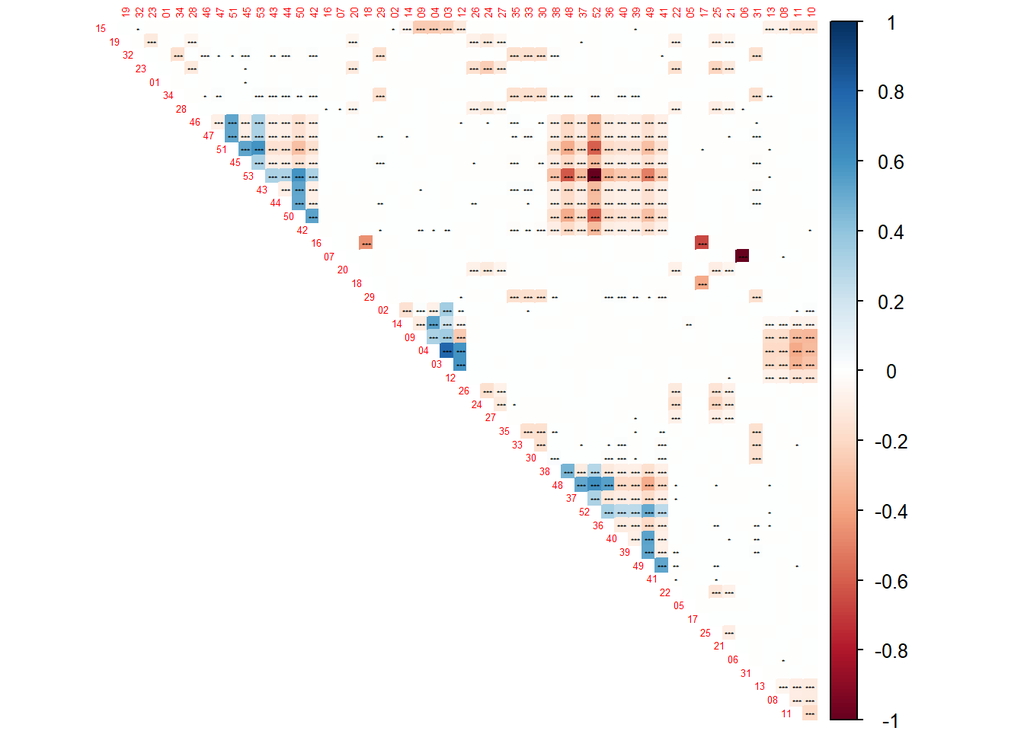

```r
# Calcula correlacoes
correlacoes <- cor(
  x = dadosParaPCA %>%
    setNames(codVariavel),
  method = "pearson"
)

# Testa de significancia
testeSignificancia <- cor.mtest(
  mat = dadosParaPCA %>%
    setNames(codVariavel),
  conf.level = 0.95
)

# Exibe grafico de correlacoes
corrplot(
  corr = correlacoes,
  p.mat = testeSignificancia$p,
  method = "color",
  diag = FALSE,
  type = "upper",
  sig.level = c(0.001, 0.01, 0.05),
  pch.cex = 0.3,
  insig = "label_sig",
  pch.col = "black",
  order = "AOE",
  tl.cex = 0.4
)
```

### Cria modelo PCA

```r
# Modelo PCA
modeloPCA <- prcomp(
  x = dadosParaPCA
)
```

#### Componentes principais

Representação dos dados por componentes principais.

```r
# Primeiros registros apos a conversao em componentes principais
modeloPCA$x %>%
  as_tibble() %>%
  head(
    n = 15
  ) %>%
  kable()
```

| PC1 | PC2 | PC3 | PC4 | PC5 | PC6 | PC7 | PC8 | PC9 | PC10 | PC11 | PC12 | PC13 | PC14 | PC15 | PC16 | PC17 | PC18 | PC19 | PC20 | PC21 | PC22 | PC23 | PC24 | PC25 | PC26 | PC27 | PC28 | PC29 | PC30 | … |
| --- | --- | --- | --- | --- | --- | --- | --- | --- | --- | --- | --- | --- | --- | --- | --- | --- | --- | --- | --- | --- | --- | --- | --- | --- | --- | --- | --- | --- | --- | --- |
| -1.5759052 | -1.2357974 | -0.8457771 | 0.7814933 | -0.9828812 | 0.6026355 | 0.7421113 | -0.0533293 | 0.7985697 | -0.5363016 | -0.3671593 | 0.7064088 | -0.4649191 | 0.0331246 | 0.7279025 | 0.4250535 | 0.2521931 | 0.0328065 | 0.0634219 | 0.0332337 | -0.1884783 | 0.0376438 | -0.0296114 | -0.1062126 | -0.0236929 | 0.0127866 | -0.6161851 | 0.0795769 | 0.0328898 | -0.0748213 | … |
| -2.4688343 | 0.6413611 | -0.7509259 | 2.8890478 | -0.9444693 | -0.8378701 | 0.1917058 | -0.0593002 | -0.8271875 | 0.7594221 | 1.0177996 | -0.0044370 | 0.1490505 | -0.1080500 | -0.0198813 | -0.0797196 | -0.4326571 | 0.6144705 | 0.2277057 | 0.4190843 | 0.2001728 | -0.0522344 | -0.1022205 | -0.1898376 | 0.0308017 | 0.0268973 | -0.0290926 | 0.6161171 | 0.0340663 | 0.5363433 | … |
| 0.1611826 | 1.5643556 | -1.3253969 | 0.9649099 | -1.0128649 | -0.8614686 | -0.6509690 | -0.0215459 | -0.7983662 | -0.6261104 | -0.2489579 | -0.0131809 | 0.7208177 | 0.0081458 | -0.1744824 | -0.4568805 | 0.7839633 | 0.2371601 | -0.1692069 | 0.0583194 | -0.5243066 | -0.0129496 | 0.0489086 | 0.0787862 | -0.0159598 | -0.0351219 | 0.1330462 | 0.1264324 | 0.1666312 | -0.7332706 | … |
| -3.9036331 | -1.1954091 | 0.7734491 | -2.8913264 | 0.7145739 | 0.5899147 | 0.7385355 | 0.9711722 | -0.0116602 | 0.9269078 | -0.2383727 | 0.0085847 | 0.2116890 | -0.1007974 | -0.0529355 | -0.0848789 | -0.4483742 | 0.6831066 | 0.2270417 | 0.4117664 | 0.6444944 | 0.0363807 | -0.3283226 | -0.7901700 | -0.6520021 | -0.0214509 | 0.0316702 | 0.1605343 | -0.7252781 | -0.1665644 | … |
| 0.9638962 | -0.8759806 | 0.7966199 | 0.4276998 | -0.9594648 | 0.5464496 | -0.6886661 | -0.0684799 | -0.7988662 | 0.1671927 | -0.1511339 | 0.7063177 | -0.4286807 | -0.0566666 | -0.0357054 | -0.0696999 | -0.4363921 | 0.6897150 | 0.2320655 | 0.4024391 | -0.1983367 | -0.2280368 | 0.0330106 | 0.2042678 | -0.0295922 | 0.0386486 | -0.1189675 | -0.7243901 | -0.1581900 | 0.2422660 | … |
| -1.5729870 | -1.2340825 | -0.8811159 | 0.7490041 | 0.7422911 | 0.5988527 | 0.7193679 | 0.9778949 | -0.0228705 | -0.5488686 | -0.3678441 | -0.0084144 | 0.0904703 | -0.0239020 | -0.1676350 | -0.4276034 | 0.7198279 | 0.2886585 | -0.1854608 | 0.0510531 | 0.2181595 | 0.0270540 | -0.0389615 | -0.1118870 | 0.0586837 | -0.0229105 | 0.0396721 | 0.0880577 | -0.7693104 | -0.1091451 | … |
| 1.3776324 | 1.0919075 | 0.3985189 | 0.0751599 | 0.9062974 | 0.5486432 | -0.6830811 | -0.6174836 | 0.0154146 | 0.3197348 | -0.1481675 | 0.0020893 | 0.1966408 | 0.6772007 | -0.0250492 | -0.1650815 | -0.4194307 | 0.6113012 | 0.2083444 | 0.4672252 | 0.4974683 | 0.3445251 | -0.3224567 | -0.2095897 | 0.6973417 | 0.9297610 | -0.0173358 | 0.0316450 | 0.0386931 | -0.0196170 | … |
| -0.2676019 | 0.8463589 | -0.6862522 | 0.4329991 | 0.9345103 | 0.5855613 | 0.7174084 | -0.6853228 | -0.0270087 | -0.5857801 | -0.3993896 | -0.6991434 | -0.4490045 | 0.0542721 | -0.0382242 | -0.2867296 | -0.0666152 | -0.3724720 | 0.7156873 | -0.1949229 | -0.1578815 | -0.0032113 | 0.7349111 | -0.2142838 | 0.0109356 | -0.2660346 | 0.0068772 | -0.0111445 | -0.0395653 | 0.0110622 | … |
| -0.6951349 | 0.0555232 | 1.4842152 | -1.1305522 | -0.9664467 | -0.8375276 | 0.7643693 | -0.0377405 | -0.8077918 | -0.5915918 | -0.3945239 | 0.0118525 | 0.7237783 | -0.0277146 | 0.0041431 | -0.2251674 | -0.2512401 | -0.5183127 | -0.4817176 | 0.4469377 | -0.5402370 | 0.0108407 | 0.0553464 | -0.0259630 | -0.0271696 | -0.0298567 | 0.1125051 | 0.1255101 | 0.1647942 | -0.7904929 | … |
| -0.2665168 | 0.7760772 | 0.9645599 | -0.7731808 | -0.9738791 | 0.5927364 | 0.7489921 | -0.0647633 | 0.8020165 | -0.5732608 | -0.3658673 | 0.7000304 | -0.4541513 | -0.0396544 | -0.0814033 | -0.1037336 | -0.4016700 | 0.6902990 | 0.2516704 | 0.4071389 | -0.1737713 | -0.0060795 | -0.0024129 | 0.0782870 | -0.0131039 | 0.0179113 | -0.6024334 | 0.1008433 | 0.0730897 | -0.0527032 | … |
| 1.3901888 | 0.3370301 | -0.5600700 | -0.2900392 | -1.0146052 | 0.5485652 | -0.6783140 | -0.0333921 | -0.7992459 | 0.2499771 | -0.1696965 | 0.0047692 | 0.7745234 | -0.6840791 | -0.0136535 | -0.0622258 | -0.4185977 | 0.6266593 | 0.2884338 | 0.3745365 | -0.5401456 | 0.3388380 | -0.0852933 | -0.1929859 | -0.0313757 | 0.0065926 | -0.0086651 | 0.6502058 | 0.0091837 | 0.5089388 | … |
| 1.4277682 | 1.0045921 | -1.1132014 | -0.5680468 | -1.0354758 | 0.5855317 | 0.7210188 | -0.0395553 | -0.8253538 | 0.1332110 | -0.3272176 | 0.0101794 | 0.1088317 | 0.0495263 | 0.7709115 | 0.4751090 | 0.2154144 | 0.0180632 | 0.0407626 | 0.0256754 | 0.1771448 | -0.1329918 | -0.1344282 | -0.3826147 | 0.0085475 | 0.0412832 | -0.1319849 | -0.7588833 | -0.1756984 | 0.2503053 | … |
| 0.8418999 | -0.8305129 | 1.8486619 | 0.7968798 | -0.9210600 | 0.5676881 | 0.1815290 | -0.0728203 | 0.8343704 | 0.0982374 | 0.9892598 | -0.0051202 | 0.7470410 | -0.0524015 | -0.0440886 | -0.0688584 | -0.4369737 | 0.6580813 | 0.2045706 | 0.3643369 | -0.5050563 | -0.9300960 | 0.0310361 | 0.0817230 | -0.0131454 | 0.0382360 | 0.7549412 | -0.0446229 | 0.0374198 | 0.0999235 | … |
| -0.2705352 | 0.8562154 | -1.0362752 | 0.7840953 | -1.0061205 | -0.8625756 | -0.6499727 | -0.0325363 | -0.7991337 | -0.6061699 | -0.2483193 | 0.0036148 | 0.1124596 | -0.0505776 | 0.0123061 | -0.2125104 | -0.2647992 | -0.5279756 | -0.4772738 | 0.4712118 | 0.1628005 | 0.0257751 | 0.0649609 | 0.0592370 | 0.0299344 | -0.0025167 | 0.1126281 | 0.1021232 | 0.1763082 | -0.7586456 | … |
| -0.2595811 | 0.7609872 | 1.3238077 | -1.1206670 | 0.7400234 | 0.5887516 | 0.7298115 | 0.9671867 | -0.0155752 | -0.5969635 | -0.3624210 | 0.7068944 | -0.4705076 | 0.0518443 | 0.7762646 | 0.4190120 | 0.2438847 | 0.0080807 | 0.0695033 | 0.0279119 | -0.1838982 | 0.0033852 | 0.0476011 | 0.0602195 | -0.0323407 | 0.0039582 | -0.0127012 | -0.0882093 | 0.4701668 | 0.1664708 | … |

#### Importance of components

Importância de cada componente principal.

```r
# Mostra componentes principais
modeloPCA %>%
  summary()
```

```
## Importance of components:
##                           PC1     PC2     PC3    PC4     PC5     PC6     PC7
## Standard deviation     1.3945 1.03370 1.00025 0.9973 0.91381 0.69338 0.62938
## Proportion of Variance 0.1803 0.09905 0.09275 0.0922 0.07741 0.04457 0.03672
## Cumulative Proportion  0.1803 0.27933 0.37208 0.4643 0.54169 0.58625 0.62297
##                            PC8     PC9    PC10    PC11    PC12    PC13    PC14
## Standard deviation     0.59112 0.55431 0.49436 0.49002 0.44704 0.41161 0.39366
## Proportion of Variance 0.03239 0.02848 0.02266 0.02226 0.01853 0.01571 0.01437
## Cumulative Proportion  0.65537 0.68385 0.70650 0.72876 0.74729 0.76299 0.77736
##                           PC15    PC16    PC17    PC18    PC19    PC20    PC21
## Standard deviation     0.38048 0.37927 0.37808 0.37766 0.37703 0.37674 0.35438
## Proportion of Variance 0.01342 0.01333 0.01325 0.01322 0.01318 0.01316 0.01164
## Cumulative Proportion  0.79078 0.80411 0.81736 0.83059 0.84376 0.85692 0.86856
##                           PC22   PC23    PC24   PC25    PC26    PC27    PC28
## Standard deviation     0.34387 0.3333 0.33213 0.3167 0.30609 0.27918 0.27800
## Proportion of Variance 0.01096 0.0103 0.01023 0.0093 0.00869 0.00722 0.00716
## Cumulative Proportion  0.87952 0.8898 0.90005 0.9093 0.91803 0.92526 0.93242
##                           PC29    PC30    PC31    PC32    PC33    PC34    PC35
## Standard deviation     0.27689 0.27654 0.27527 0.27349 0.26602 0.26147 0.22743
## Proportion of Variance 0.00711 0.00709 0.00702 0.00693 0.00656 0.00634 0.00479
## Cumulative Proportion  0.93953 0.94662 0.95364 0.96058 0.96714 0.97347 0.97827
##                          PC36    PC37    PC38   PC39    PC40      PC41
## Standard deviation     0.2252 0.22356 0.22254 0.2203 0.18893 1.719e-14
## Proportion of Variance 0.0047 0.00463 0.00459 0.0045 0.00331 0.000e+00
## Cumulative Proportion  0.9830 0.98760 0.99219 0.9967 1.00000 1.000e+00
##                             PC42      PC43      PC44      PC45      PC46
## Standard deviation     1.604e-14 5.493e-15 4.412e-15 4.127e-15 3.665e-15
## Proportion of Variance 0.000e+00 0.000e+00 0.000e+00 0.000e+00 0.000e+00
## Cumulative Proportion  1.000e+00 1.000e+00 1.000e+00 1.000e+00 1.000e+00
##                             PC47      PC48      PC49      PC50      PC51
## Standard deviation     3.645e-15 2.934e-15 2.912e-15 2.321e-15 2.206e-15
## Proportion of Variance 0.000e+00 0.000e+00 0.000e+00 0.000e+00 0.000e+00
## Cumulative Proportion  1.000e+00 1.000e+00 1.000e+00 1.000e+00 1.000e+00
##                             PC52      PC53
## Standard deviation     1.325e-15 9.992e-17
## Proportion of Variance 0.000e+00 0.000e+00
## Cumulative Proportion  1.000e+00 1.000e+00
```

#### Variância acumulada por componentes principais

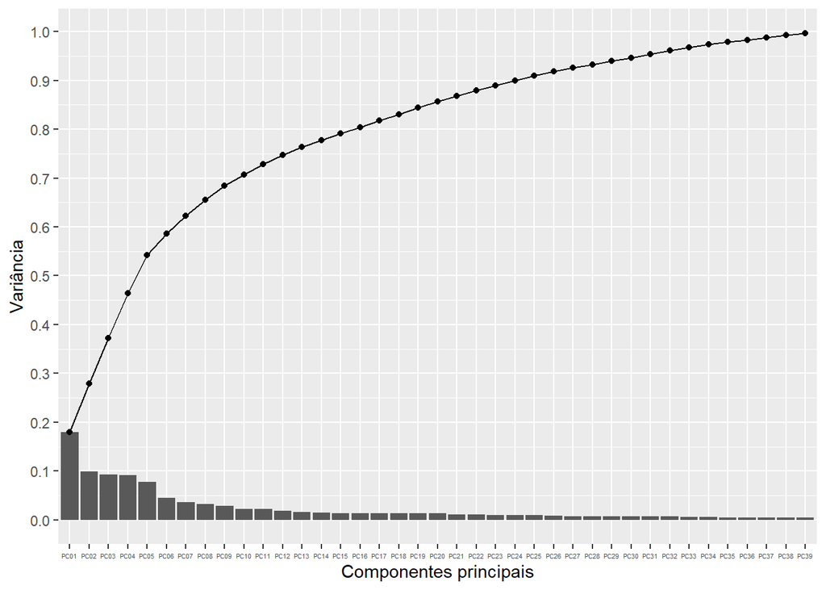

```r
modeloPCA %>%
  summary() %>%
  .$importance %>%
  as.data.frame() %>%
  rownames_to_column(
    var = "Medida"
  ) %>%
  as_tibble() %>%
  gather(
    key = "PC",
    value = "Valor",
    -Medida
  ) %>%
  mutate(
    PC = str_extract(
      string = PC,
      pattern = "[:digit:]*$"
    ) %>%
      str_pad(
        width = 2L,
        side = "left",
        pad = "0"
      ) %>%
      str_c("PC", .) %>%
      factor()
  ) %>%
  spread(
    key = Medida,
    value = Valor
  ) %>%
  filter(
    `Cumulative Proportion` < 1
  ) %>%
  ggplot() +
  geom_bar(
    aes(
      x = PC,
      y = `Proportion of Variance`
    ),
    stat = "identity"
  ) +
  geom_point(
    aes(
      x = PC,
      y = `Cumulative Proportion`
    )
  ) +
  geom_line(
    aes(
      x = PC,
      y = `Cumulative Proportion`,
      group = 1
    )
  ) +
  xlab(
    label = "Componentes principais"
  ) +
  ylab(
    label = "Variância"
  ) +
  scale_y_continuous(
    n.breaks = 10
  ) +
  theme(
    axis.text.x = element_text(
      size = 4
    )
  )
```

## Referências

Duboue, P. (2020). The Art of Feature Engineering: Essentials for Machine Learning. Reino Unido: Cambridge University Press.

Feature Engineering for Machine Learning and Data Analytics. (2018). Reino Unido: CRC Press.

Kaufman, L. and Rousseeuw, P.J. (1990). Clustering Large Applications (Program CLARA). In Finding Groups in Data (eds L. Kaufman and P.J. Rousseeuw). https://doi.org/10.1002/9780470316801.ch3

Kuhn, M., Johnson, K. (2019). Feature Engineering and Selection: A Practical Approach for Predictive Models. Reino Unido: CRC Press.